# R Notebook for Manuscript of Panic Disorder Prevalence

```r
library('lmtest');
library('tseries');
library('changepoint');
library('forecast');
library('cardidates');
```

# Read data

```r
require(readxl)
setwd("~/Dropbox/gitLab/studyDepressionBigData/panicPrevalence/")
DTPANIC<- read_xlsx("PanicWholePopu.xlsx",sheet = "PANIC")
mTotPopulation=DTPANIC$totN1;
nPrevPANIC4=DTPANIC$prevN4/mTotPopulation*100;
nNPrevPANIC4=DTPANIC$inciN4/mTotPopulation*100;
DTOCD<- read_xlsx("PanicWholePopu.xlsx",sheet = "OCD")
nPrevOCD4=DTOCD$prevN4/mTotPopulation*100;
nNPrevOCD4=DTOCD$inciN4/mTotPopulation*100;
```

# Read Google Trends

```r
sPanicDis=read.csv(file="~/Dropbox/gitLab/studyDepressionBigData/panicDisorder20142021.csv", header=FALSE);
sOCDDis=read.csv(file="~/Dropbox/gitLab/studyDepressionBigData/OCDDisorder20142029.csv", header=FALSE);
sPanicOCDDis=read.csv(file="~/Dropbox/gitLab/studyDepressionBigData/PanicOCDDisorder20142029.csv", header=FALSE);
sChaPanicDis=read.csv(file="~/Dropbox/gitLab/studyDepressionBigData/googChaPanicDis.csv", header=FALSE);
sLeePanicDis=read.csv(file="~/Dropbox/gitLab/studyDepressionBigData/googLeePanicDis.csv", header=FALSE);
sKimPanicDis=read.csv(file="~/Dropbox/gitLab/studyDepressionBigData/googKimPanicDis.csv", header=FALSE);
```

# Make dataframe

```r
data <- data.frame(
month = as.ts(sPanicDis$V1, format="%Y-%m"),
prevPANIC4 = nPrevPANIC4,
prevOCD4 = nPrevOCD4,
inciPANIC4 = nNPrevPANIC4,
inciOCD4 = nNPrevOCD4,

google = sPanicDis$V2,
googleOCD = sOCDDis$V2,
googleOCDrelative = sPanicOCDDis$V3,
googCha = c(sChaPanicDis$V2,rep(0,96)),
googLee = c(sLeePanicDis$V2,rep(0,96)),
googKim = c(sKimPanicDis$V2,rep(0,96))
)

google.ts=ts(data$google,frequency=12, start=c(2004,1))
googleOCD.ts=ts(data$googleOCD,frequency=12, start=c(2004,1))
googleOCDrelative.ts=ts(data$googleOCDrelative,frequency=12, start=c(2004,1))
prevPANIC4.ts=ts(data$prevPANIC4,frequency=12, start=c(2004,1))
prevOCD4.ts=ts(data$prevOCD4, frequency = 12, start = c(2004,1))
inciPANIC4.ts=ts(data$inciPANIC4,frequency=12, start=c(2004,1) )
inciOCD4.ts=ts(data$inciOCD4,frequency=12, start=c(2004,1) )
```

# Draw graph of incidence and google data

```r
inciNEURO2.ts=ts.union(inciPANIC.ts, inciOCD.ts);
plot(inciNEURO2.ts, type="l", plot.type="s", col=c("blue","cyan"), xlab="Month", ylab="Pat. N", linetype=c("solid","dashed"), ylim=c(0,max(inciPANIC.ts)))
legend("topleft", inset = 0.02, legend=c("PANIC","OCD"),
       col=c("blue", "cyan"), lty=1, cex=0.8)
```

```r
polygon(c(min(index(google.ts)),index(google.ts), max(index(google.ts))), c(0, google.ts*max(inciPANIC.ts)/100,0),col="blue")
polygon(c(min(index(googleOCDrelative.ts)),index(googleOCDrelative.ts), max(index(googleOCDrelative.ts))), c(0, googleOCDrelative.ts*max(inciPANIC.ts)/100,0),col="green")
```

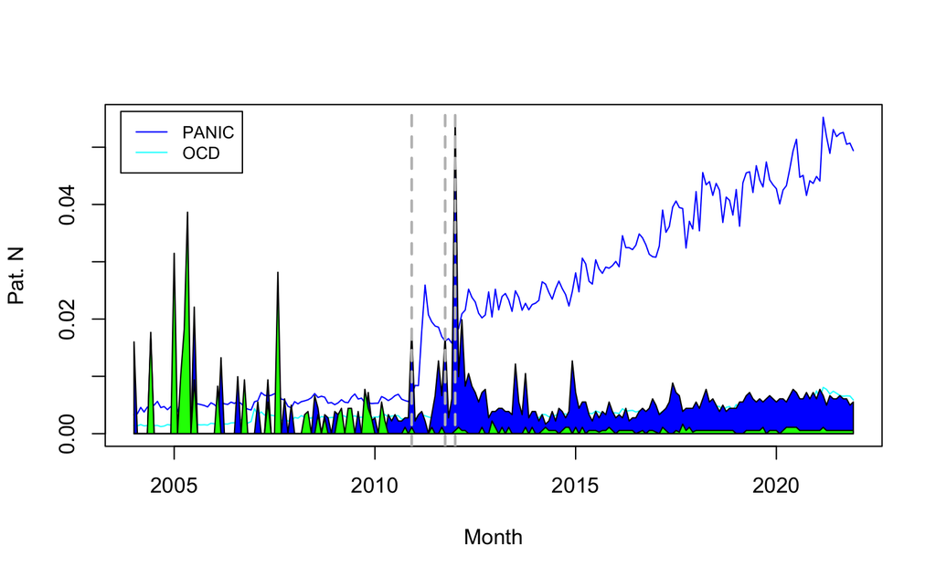

```r
# Add vertical lines indicating date of celerbity disclosures
abline(v=c(2004+(which(data$googCha == 100)-1)/120*10,2004+(which(data$googKim == 100)-1)/120*10,2004+(which(data$googLee == 100)-1)/120*10), col="gray", lty="dashed", lwd=2)
```

```r
#dev.off()
```

# Make transfer fuction matrix

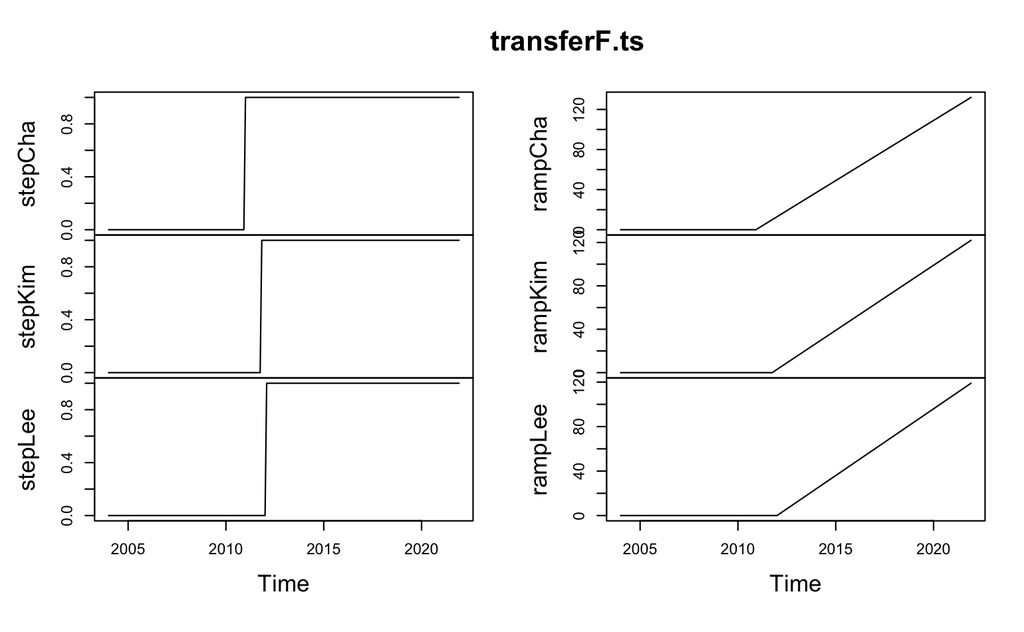

```r
countN=1:216;
monthCha=which(data$googCha == 100);
monthKim=which(data$googKim == 100);
monthLee=which(data$googLee == 100);

stepCha = as.numeric(countN > monthCha)
stepKim = as.numeric(countN > monthKim)
stepLee = as.numeric(countN > monthLee)
rampCha <- append(rep(0,monthCha), seq(1,216-monthCha,1))
rampKim <- append(rep(0,monthKim), seq(1,216-monthKim,1))
rampLee <- append(rep(0,monthLee), seq(1,216-monthLee,1))
transferF=cbind(stepCha,stepKim,stepLee,rampCha,rampKim,rampLee)
transferF.ts=ts(transferF,frequency=12, start=c(2004,1))
transferFGoogle=as.numeric(google.ts)
transferFGoogle.ts=ts(transferF,frequency=12, start=c(2004,1))

plot(transferF.ts)
```

# Check autocorrelation

```
     [,1] [,2]  [,3]  [,4]  [,5] [,6]  [,7] [,8]  [,9] [,10] [,11] [,12] [,13] [,14] [,15] [,16] [,17] [,18] [,19] [,20] [,21] [,22] [,23] [,24]
ACF  0.98 0.96  0.95  0.93  0.91 0.90  0.89 0.88  0.87  0.85  0.84  0.84  0.82  0.81  0.80  0.79  0.77  0.76  0.74  0.73  0.72  0.71  0.70  0.69
PACF 0.98 0.17 -0.01 -0.01 -0.02 0.08 -0.01 0.11 -0.02 -0.10  0.09  0.09 -0.15  0.02 -0.03  0.00 -0.04 -0.06  0.07  0.03 -0.03  0.07 -0.03 -0.02
```

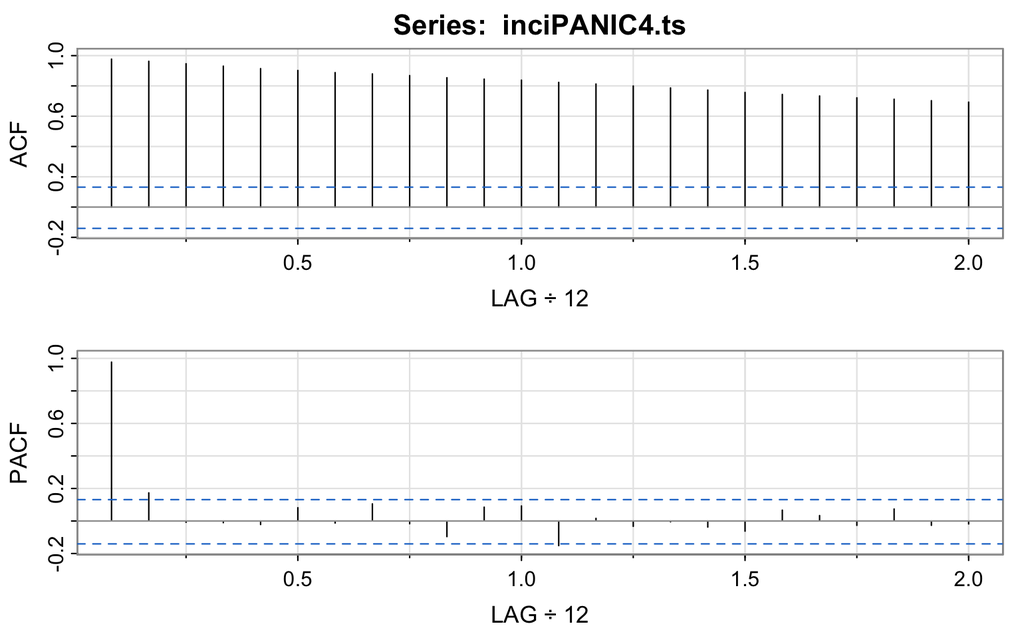

```r
acf2(inciPANIC4.ts, max.lag=24)
```

```
     [,1] [,2] [,3] [,4] [,5] [,6]  [,7]  [,8] [,9] [,10] [,11] [,12] [,13] [,14] [,15] [,16] [,17] [,18] [,19] [,20] [,21] [,22] [,23] [,24]
ACF  0.69 0.57 0.45 0.39 0.34 0.35  0.30  0.23 0.26  0.14  0.08 -0.05  0.05  0.08  0.07  0.08  0.07  0.05  0.08  0.06  0.00 -0.06 -0.09 -0.17
PACF 0.69 0.18 0.01 0.07 0.02 0.12 -0.02 -0.07 0.14 -0.21 -0.07 -0.18  0.26  0.10 -0.13  0.09  0.02  0.01  0.09 -0.14  0.04 -0.28 -0.07 -0.16
```

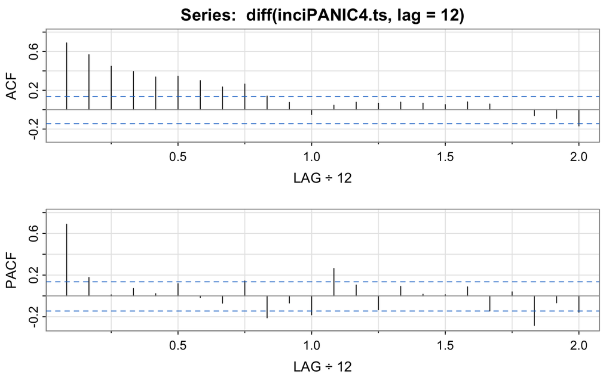

```r
acf2(diff(inciPANIC4.ts,lag=12), max.lag=24)
```

```
      [,1]  [,2]  [,3] [,4]  [,5]  [,6] [,7]  [,8] [,9] [,10] [,11] [,12] [,13] [,14] [,15] [,16] [,17] [,18] [,19] [,20] [,21] [,22] [,23] [,24]
ACF  -0.31 -0.01 -0.10  0.0 -0.09  0.08 0.03 -0.16 0.24 -0.08  0.10 -0.36  0.11  0.08 -0.05  0.04  0.00 -0.07  0.09  0.07  0.00 -0.06  0.09 -0.22
PACF -0.31 -0.12 -0.16 -0.1 -0.17 -0.03 0.02 -0.20 0.15  0.02  0.12 -0.31 -0.14  0.11 -0.12 -0.06 -0.04 -0.12  0.12 -0.06  0.23  0.02  0.11 -0.29
```

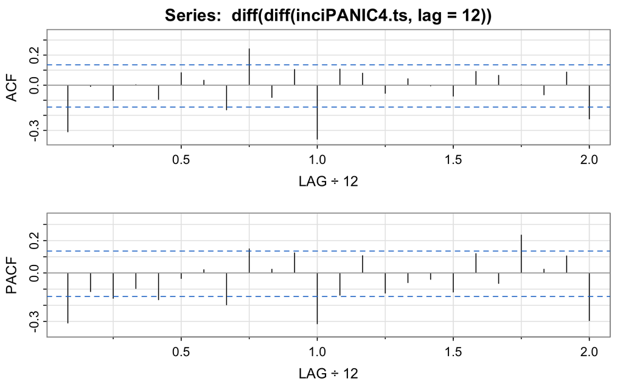

```r
acf2(diff(diff(inciPANIC4.ts,lag=12)), max.lag=24)
```

Below is the selected model of incidence. In the text:Only the first celebrity disclosure significantly increased both the level (0·0058%, 95% CI: 0·0022%–0·0095%, p < 0·005) and slope of the monthly incidence of panic disorder (0·00078% per month, 95% CI 0·00019%–0·0014% per month, p < 0·01). # Modeling

```r
incimodel4 <- auto.arima(inciPANIC4.ts, seasonal=TRUE, xreg=transferF, max.d=3, max.D=3, stepwise=FALSE, trace=TRUE);
```

```
 Fitting models using approximations to speed things up...

 Regression with ARIMA(0,0,0)            errors : -1744.304
 Regression with ARIMA(0,0,0)            errors : -1985.792
 Regression with ARIMA(0,0,0)(0,0,1)[12] errors : -1858.405
 Regression with ARIMA(0,0,0)(0,0,1)[12] errors : Inf
 Regression with ARIMA(0,0,0)(0,0,2)[12] errors : Inf
 Regression with ARIMA(0,0,0)(0,0,2)[12] errors : Inf
 Regression with ARIMA(0,0,0)(1,0,0)[12] errors : -1959.339
 Regression with ARIMA(0,0,0)(1,0,0)[12] errors : -2008.507
 Regression with ARIMA(0,0,0)(1,0,1)[12] errors : Inf
 Regression with ARIMA(0,0,0)(1,0,1)[12] errors : Inf
 Regression with ARIMA(0,0,0)(1,0,2)[12] errors : Inf
 Regression with ARIMA(0,0,0)(1,0,2)[12] errors : Inf
 Regression with ARIMA(0,0,0)(2,0,0)[12] errors : Inf
 Regression with ARIMA(0,0,0)(2,0,0)[12] errors : -1994.217
 Regression with ARIMA(0,0,0)(2,0,1)[12] errors : Inf
 Regression with ARIMA(0,0,0)(2,0,1)[12] errors : Inf
 Regression with ARIMA(0,0,0)(2,0,2)[12] errors : Inf
 Regression with ARIMA(0,0,0)(2,0,2)[12] errors : Inf
 Regression with ARIMA(0,0,1)            errors : -1847.789
 Regression with ARIMA(0,0,1)            errors : -2010.496
 Regression with ARIMA(0,0,1)(0,0,1)[12] errors : -1932.638
 Regression with ARIMA(0,0,1)(0,0,1)[12] errors : Inf
 Regression with ARIMA(0,0,1)(0,0,2)[12] errors : -1939.038
 Regression with ARIMA(0,0,1)(0,0,2)[12] errors : Inf
 Regression with ARIMA(0,0,1)(1,0,0)[12] errors : -1988.242
 Regression with ARIMA(0,0,1)(1,0,0)[12] errors : Inf
 Regression with ARIMA(0,0,1)(1,0,1)[12] errors : Inf
 Regression with ARIMA(0,0,1)(1,0,1)[12] errors : Inf
 Regression with ARIMA(0,0,1)(1,0,2)[12] errors : Inf
 Regression with ARIMA(0,0,1)(1,0,2)[12] errors : Inf
 Regression with ARIMA(0,0,1)(2,0,0)[12] errors : -1988.01
 Regression with ARIMA(0,0,1)(2,0,0)[12] errors : -2018.107
 Regression with ARIMA(0,0,1)(2,0,1)[12] errors : Inf
 Regression with ARIMA(0,0,1)(2,0,1)[12] errors : Inf
 Regression with ARIMA(0,0,1)(2,0,2)[12] errors : Inf
 Regression with ARIMA(0,0,1)(2,0,2)[12] errors : Inf
 Regression with ARIMA(0,0,2)            errors : -1903.597
 Regression with ARIMA(0,0,2)            errors : -2019.842
```

[output cut: 146 more lines]

```
 Regression with ARIMA(4,0,0)(0,0,1)[12] errors : -2011.971
 Regression with ARIMA(4,0,0)(0,0,1)[12] errors : Inf
 Regression with ARIMA(4,0,0)(1,0,0)[12] errors : -2006.8
 Regression with ARIMA(4,0,0)(1,0,0)[12] errors : Inf
 Regression with ARIMA(4,0,1)            errors : Inf
 Regression with ARIMA(4,0,1)            errors : -2016.639
 Regression with ARIMA(5,0,0)            errors : -1982.65
 Regression with ARIMA(5,0,0)            errors : -2019.662

 Now re-fitting the best model(s) without approximations...




 Best model: Regression with ARIMA(1,0,0)(0,0,1)[12] errors
```

```
    Ljung-Box test

data:  Residuals from Regression with ARIMA(1,0,0)(0,0,1)[12] errors
Q* = 20.216, df = 22, p-value = 0.5695

Model df: 2.   Total lags used: 24
```

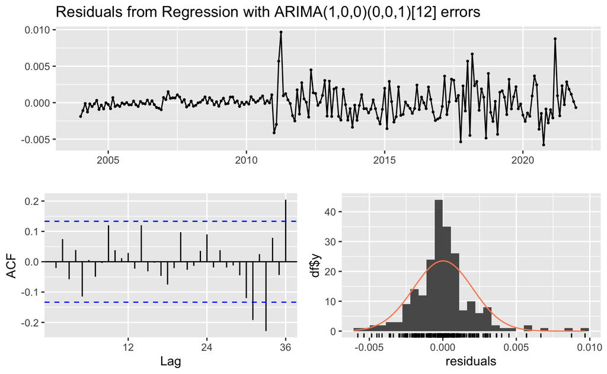

```r
checkresiduals(incimodel4)
```

```r
Box.test(incimodel4$residuals, lag = 24, type = "Ljung-Box")
```

```
    Box-Ljung test

data:  incimodel4$residuals
X-squared = 20.216, df = 24, p-value = 0.6844
```

```r
summary(incimodel4)
```

```
Series: inciPANIC4.ts
Regression with ARIMA(1,0,0)(0,0,1)[12] errors

Coefficients:
         ar1    sma1  intercept  stepCha  stepKim  stepLee  rampCha  rampKim  rampLee
      0.3953  0.3734     0.0055   0.0058  -0.0039    8e-04    8e-04  -0.0001  -0.0004
s.e.  0.0662  0.1349     0.0005   0.0019   0.0030    2e-03    3e-04   0.0015   0.0013

sigma^2 = 4.25e-06:  log likelihood = 1032.92
AIC=-2045.84   AICc=-2044.77   BIC=-2012.09

Training set error measures:
                       ME        RMSE         MAE       MPE    MAPE      MASE        ACF1
Training set 1.431561e-05 0.002018219 0.001366502 -1.071599 7.48214 0.4412333 -0.02085657
```

```r
confint(incimodel4)
```

```
                  2.5 %      97.5 %
ar1        0.2654833303 0.525096435
sma1       0.1090416493 0.637782243
intercept  0.0045494745 0.006443885
stepCha    0.0021693392 0.009495776
stepKim   -0.0096708467 0.001970305
stepLee   -0.0030503483 0.004735527
rampCha    0.0001911517 0.001369437
rampKim   -0.0029191621 0.002799575
rampLee   -0.0030324226 0.002144572
```

```r
coeftest(incimodel4)
```

```
z test of coefficients:

             Estimate  Std. Error z value  Pr(>|z|)
ar1        3.9529e-01  6.6229e-02  5.9685 2.394e-09 ***
sma1       3.7341e-01  1.3489e-01  2.7684  0.005634 **
intercept  5.4967e-03  4.8328e-04 11.3738 < 2.2e-16 ***
stepCha    5.8326e-03  1.8690e-03  3.1206  0.001805 **
stepKim   -3.8503e-03  2.9697e-03 -1.2965  0.194802
stepLee    8.4259e-04  1.9862e-03  0.4242  0.671409
rampCha    7.8029e-04  3.0059e-04  2.5959  0.009435 **
rampKim   -5.9794e-05  1.4589e-03 -0.0410  0.967307
rampLee   -4.4393e-04  1.3207e-03 -0.3361  0.736771
---
Signif. codes:  0 ‘***’ 0.001 ‘**’ 0.01 ‘*’ 0.05 ‘.’ 0.1 ‘ ’ 1
```

# OCD model

```r
modelOCD4 <- auto.arima(inciOCD4.ts, seasonal=TRUE, xreg=transferF, max.d=3, max.D=3, stepwise=FALSE, trace=TRUE);
```

```
 Fitting models using approximations to speed things up...

 Regression with ARIMA(0,0,0)            errors : -2148.121
 Regression with ARIMA(0,0,0)            errors : -2523.449
 Regression with ARIMA(0,0,0)(0,0,1)[12] errors : Inf
 Regression with ARIMA(0,0,0)(0,0,1)[12] errors : Inf
 Regression with ARIMA(0,0,0)(0,0,2)[12] errors : -2385.86
 Regression with ARIMA(0,0,0)(0,0,2)[12] errors : -2577.604
 Regression with ARIMA(0,0,0)(1,0,0)[12] errors : Inf
 Regression with ARIMA(0,0,0)(1,0,0)[12] errors : -2599.654
 Regression with ARIMA(0,0,0)(1,0,1)[12] errors : Inf
 Regression with ARIMA(0,0,0)(1,0,1)[12] errors : -2599.844
 Regression with ARIMA(0,0,0)(1,0,2)[12] errors : Inf
 Regression with ARIMA(0,0,0)(1,0,2)[12] errors : Inf
 Regression with ARIMA(0,0,0)(2,0,0)[12] errors : Inf
 Regression with ARIMA(0,0,0)(2,0,0)[12] errors : -2595.71
 Regression with ARIMA(0,0,0)(2,0,1)[12] errors : Inf
 Regression with ARIMA(0,0,0)(2,0,1)[12] errors : -2597.981
 Regression with ARIMA(0,0,0)(2,0,2)[12] errors : Inf
 Regression with ARIMA(0,0,0)(2,0,2)[12] errors : Inf
 Regression with ARIMA(0,0,1)            errors : -2336.93
 Regression with ARIMA(0,0,1)            errors : -2618.476
 Regression with ARIMA(0,0,1)(0,0,1)[12] errors : Inf
 Regression with ARIMA(0,0,1)(0,0,1)[12] errors : Inf
 Regression with ARIMA(0,0,1)(0,0,2)[12] errors : -2507.29
 Regression with ARIMA(0,0,1)(0,0,2)[12] errors : -2658.691
 Regression with ARIMA(0,0,1)(1,0,0)[12] errors : Inf
 Regression with ARIMA(0,0,1)(1,0,0)[12] errors : -2674.429
 Regression with ARIMA(0,0,1)(1,0,1)[12] errors : Inf
 Regression with ARIMA(0,0,1)(1,0,1)[12] errors : -2678.233
 Regression with ARIMA(0,0,1)(1,0,2)[12] errors : Inf
 Regression with ARIMA(0,0,1)(1,0,2)[12] errors : Inf
 Regression with ARIMA(0,0,1)(2,0,0)[12] errors : Inf
 Regression with ARIMA(0,0,1)(2,0,0)[12] errors : -2669.216
 Regression with ARIMA(0,0,1)(2,0,1)[12] errors : Inf
 Regression with ARIMA(0,0,1)(2,0,1)[12] errors : -2668.942
 Regression with ARIMA(0,0,1)(2,0,2)[12] errors : Inf
 Regression with ARIMA(0,0,1)(2,0,2)[12] errors : -2670.428
 Regression with ARIMA(0,0,2)            errors : -2457.059
 Regression with ARIMA(0,0,2)            errors : -2670.056
```

[output cut: 146 more lines]

```
 Regression with ARIMA(4,0,0)(0,0,1)[12] errors : -2745.509
 Regression with ARIMA(4,0,0)(0,0,1)[12] errors : -2753.125
 Regression with ARIMA(4,0,0)(1,0,0)[12] errors : -2741.077
 Regression with ARIMA(4,0,0)(1,0,0)[12] errors : -2749.589
 Regression with ARIMA(4,0,1)            errors : Inf
 Regression with ARIMA(4,0,1)            errors : Inf
 Regression with ARIMA(5,0,0)            errors : Inf
 Regression with ARIMA(5,0,0)            errors : -2738.468

 Now re-fitting the best model(s) without approximations...




 Best model: Regression with ARIMA(1,0,2)(0,0,2)[12] errors
```

```
    Ljung-Box test

data:  Residuals from Regression with ARIMA(1,0,2)(0,0,2)[12] errors
Q* = 16.208, df = 19, p-value = 0.6433

Model df: 5.   Total lags used: 24
```

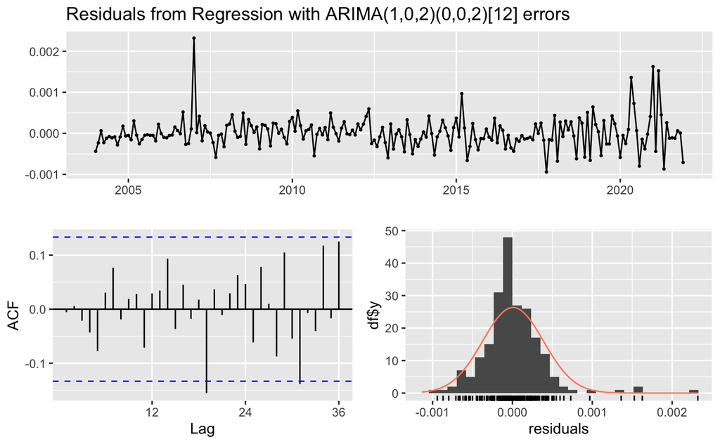

```r
checkresiduals(modelOCD4)
```

```r
Box.test(modelOCD4$residuals, lag = 24, type = "Ljung-Box")
```

```
    Box-Ljung test

data:  modelOCD4$residuals
X-squared = 16.208, df = 24, p-value = 0.8804
```

```r
summary(modelOCD4)
```

```
Series: inciOCD4.ts
Regression with ARIMA(1,0,2)(0,0,2)[12] errors

Coefficients:
         ar1      ma1     ma2    sma1    sma2  intercept  stepCha  stepKim  stepLee  rampCha  rampKim  rampLee
      0.8865  -0.3684  0.0845  0.2223  0.1885     0.0022    1e-04    2e-04    4e-04        0   -1e-04    1e-04
s.e.  0.0451   0.0775  0.0787  0.0781  0.0766     0.0003    4e-04    5e-04    4e-04        0    3e-04    2e-04

sigma^2 = 1.532e-07:  log likelihood = 1393.15
AIC=-2760.29   AICc=-2758.49   BIC=-2716.42

Training set error measures:
                       ME         RMSE          MAE        MPE     MAPE      MASE         ACF1
Training set 7.749073e-06 0.0003803332 0.0002557093 -0.8780508 7.511036 0.5063964 -0.005505008
```

```r
confint(modelOCD4)
```

```
                  2.5 %        97.5 %
ar1        7.980910e-01  9.748648e-01
ma1       -5.203974e-01 -2.164610e-01
ma2       -6.971391e-02  2.386206e-01
sma1       6.919980e-02  3.754006e-01
sma2       3.836636e-02  3.385606e-01
intercept  1.577551e-03  2.881159e-03
stepCha   -7.107179e-04  8.381240e-04
stepKim   -7.377225e-04  1.216371e-03
stepLee   -2.739021e-04  1.127489e-03
rampCha   -4.520873e-05  4.977057e-05
rampKim   -5.833641e-04  4.217350e-04
rampLee   -3.526964e-04  5.653215e-04
```

```r
coeftest(modelOCD4)
```

```
z test of coefficients:

             Estimate  Std. Error z value  Pr(>|z|)
ar1        8.8648e-01  4.5096e-02 19.6575 < 2.2e-16 ***
ma1       -3.6843e-01  7.7536e-02 -4.7517 2.017e-06 ***
ma2        8.4453e-02  7.8658e-02  1.0737  0.282968
sma1       2.2230e-01  7.8114e-02  2.8458  0.004429 **
sma2       1.8846e-01  7.6582e-02  2.4610  0.013857 *
intercept  2.2294e-03  3.3256e-04  6.7036 2.033e-11 ***
stepCha    6.3703e-05  3.9512e-04  0.1612  0.871916
stepKim    2.3932e-04  4.9850e-04  0.4801  0.631166
stepLee    4.2679e-04  3.5750e-04  1.1938  0.232551
rampCha    2.2809e-06  2.4230e-05  0.0941  0.925001
rampKim   -8.0814e-05  2.5641e-04 -0.3152  0.752625
rampLee    1.0631e-04  2.3419e-04  0.4540  0.649862
---
Signif. codes:  0 ‘***’ 0.001 ‘**’ 0.01 ‘*’ 0.05 ‘.’ 0.1 ‘ ’ 1
```

Significance was found in two cases:grangertest(diff(prevPANIC4.ts) ~ google.ts[-216], order=2) and grangertest(diff(prevPANIC4.ts) ~ google.ts[-216], order=3). A significant p-value in the context of the ADF test suggests that the time series is likely stationary. A significant p-value was found in google.ts and diff(prevPANIC4.ts) diff(inciPANIC4.ts). In the manuscript: The monthly incidence and prevalence were nonstationary (ADF = -2·98, p = 0·17 and ADF = -0·73, p = 0·97 for incidence and prevalence, respectively); the first-order differences in the monthly incidence and prevalence of panic disorder were stationary (ADF = -8·19, p < 0·05 and ADF = -7·14, p < 0·05 for incidence and prevalence, respectively).

# Google Trend and Incidence

```r
library(tseries)
adf.test(google.ts, alternative = "stationary")
```

```
    Augmented Dickey-Fuller Test

data:  google.ts
Dickey-Fuller = -4.1402, Lag order = 5, p-value = 0.01
alternative hypothesis: stationary
```

```r
adf.test(inciPANIC4.ts, alternative = "stationary")
```

```
    Augmented Dickey-Fuller Test

data:  inciPANIC4.ts
Dickey-Fuller = -2.9771, Lag order = 5, p-value = 0.1661
alternative hypothesis: stationary
```

```r
adf.test(prevPANIC4.ts, alternative = "stationary")
```

```
    Augmented Dickey-Fuller Test

data:  prevPANIC4.ts
Dickey-Fuller = -0.72732, Lag order = 5, p-value = 0.9668
alternative hypothesis: stationary
```

```r
adf.test(diff(inciPANIC4.ts), alternative = "stationary")
```

```
    Augmented Dickey-Fuller Test

data:  diff(inciPANIC4.ts)
Dickey-Fuller = -8.1899, Lag order = 5, p-value = 0.01
alternative hypothesis: stationary
```

```r
adf.test(diff(prevPANIC4.ts), alternative = "stationary")
```

```
    Augmented Dickey-Fuller Test

data:  diff(prevPANIC4.ts)
Dickey-Fuller = -7.1425, Lag order = 5, p-value = 0.01
alternative hypothesis: stationary
```

```r
cor.test(diff(inciPANIC4.ts), google.ts[-216],  method="spearman", exact=FALSE)
```

```
    Spearman's rank correlation rho

data:  diff(inciPANIC4.ts) and google.ts[-216]
S = 1647882, p-value = 0.9405
alternative hypothesis: true rho is not equal to 0
sample estimates:
        rho
0.005118754
```

```r
cor.test(diff(prevPANIC4.ts), google.ts[-216],  method="spearman", exact=FALSE)
```

```
    Spearman's rank correlation rho

data:  diff(prevPANIC4.ts) and google.ts[-216]
S = 1342497, p-value = 0.005311
alternative hypothesis: true rho is not equal to 0
sample estimates:
      rho
0.1894897
```

```r
grangertest(diff(prevPANIC4.ts) ~ google.ts[-216], order=4)
```

```
Granger causality test

Model 1: diff(prevPANIC4.ts) ~ Lags(diff(prevPANIC4.ts), 1:4) + Lags(google.ts[-216], 1:4)
Model 2: diff(prevPANIC4.ts) ~ Lags(diff(prevPANIC4.ts), 1:4)
  Res.Df Df      F  Pr(>F)
1    202
2    206 -4 1.9743 0.09979 .
---
Signif. codes:  0 ‘***’ 0.001 ‘**’ 0.01 ‘*’ 0.05 ‘.’ 0.1 ‘ ’ 1
```

```r
grangertest(google.ts[-216] ~ diff(prevPANIC4.ts), order=4)
```

```
Granger causality test

Model 1: google.ts[-216] ~ Lags(google.ts[-216], 1:4) + Lags(diff(prevPANIC4.ts), 1:4)
Model 2: google.ts[-216] ~ Lags(google.ts[-216], 1:4)
  Res.Df Df      F Pr(>F)
1    202
2    206 -4 0.7346 0.5694
```

```r
grangertest(diff(prevPANIC4.ts) ~ google.ts[-216], order=3)
```

```
Granger causality test

Model 1: diff(prevPANIC4.ts) ~ Lags(diff(prevPANIC4.ts), 1:3) + Lags(google.ts[-216], 1:3)
Model 2: diff(prevPANIC4.ts) ~ Lags(diff(prevPANIC4.ts), 1:3)
  Res.Df Df      F  Pr(>F)
1    205
2    208 -3 3.1082 0.02748 *
---
Signif. codes:  0 ‘***’ 0.001 ‘**’ 0.01 ‘*’ 0.05 ‘.’ 0.1 ‘ ’ 1
```

```r
grangertest(diff(prevPANIC4.ts) ~ google.ts[-216], order=2)
```

```
Granger causality test

Model 1: diff(prevPANIC4.ts) ~ Lags(diff(prevPANIC4.ts), 1:2) + Lags(google.ts[-216], 1:2)
Model 2: diff(prevPANIC4.ts) ~ Lags(diff(prevPANIC4.ts), 1:2)
  Res.Df Df      F  Pr(>F)
1    208
2    210 -2 4.2575 0.01541 *
---
Signif. codes:  0 ‘***’ 0.001 ‘**’ 0.01 ‘*’ 0.05 ‘.’ 0.1 ‘ ’ 1
```

```r
grangertest(diff(prevPANIC4.ts) ~ google.ts[-216], order=1)
```

```
Granger causality test

Model 1: diff(prevPANIC4.ts) ~ Lags(diff(prevPANIC4.ts), 1:1) + Lags(google.ts[-216], 1:1)
Model 2: diff(prevPANIC4.ts) ~ Lags(diff(prevPANIC4.ts), 1:1)
  Res.Df Df      F Pr(>F)
1    211
2    212 -1 2.4692 0.1176
```

```r
grangertest(google.ts[-216] ~ diff(prevPANIC4.ts), order=3)
```

```
Granger causality test

Model 1: google.ts[-216] ~ Lags(google.ts[-216], 1:3) + Lags(diff(prevPANIC4.ts), 1:3)
Model 2: google.ts[-216] ~ Lags(google.ts[-216], 1:3)
  Res.Df Df      F Pr(>F)
1    205
2    208 -3 0.9343  0.425
```

```r
grangertest(diff(prevPANIC4.ts) ~ google.ts[-216], order=2)
```

```
Granger causality test

Model 1: diff(prevPANIC4.ts) ~ Lags(diff(prevPANIC4.ts), 1:2) + Lags(google.ts[-216], 1:2)
Model 2: diff(prevPANIC4.ts) ~ Lags(diff(prevPANIC4.ts), 1:2)
  Res.Df Df      F  Pr(>F)
1    208
2    210 -2 4.2575 0.01541 *
---
Signif. codes:  0 ‘***’ 0.001 ‘**’ 0.01 ‘*’ 0.05 ‘.’ 0.1 ‘ ’ 1
```

```r
grangertest(google.ts[-216] ~ diff(prevPANIC4.ts), order=2)
```

```
Granger causality test

Model 1: google.ts[-216] ~ Lags(google.ts[-216], 1:2) + Lags(diff(prevPANIC4.ts), 1:2)
Model 2: google.ts[-216] ~ Lags(google.ts[-216], 1:2)
  Res.Df Df      F Pr(>F)
1    208
2    210 -2 1.3733 0.2556
```

```r
grangertest(diff(prevPANIC4.ts) ~ google.ts[-216], order=1)
```

```
Granger causality test

Model 1: diff(prevPANIC4.ts) ~ Lags(diff(prevPANIC4.ts), 1:1) + Lags(google.ts[-216], 1:1)
Model 2: diff(prevPANIC4.ts) ~ Lags(diff(prevPANIC4.ts), 1:1)
  Res.Df Df      F Pr(>F)
1    211
2    212 -1 2.4692 0.1176
```

```r
grangertest(google.ts[-216] ~ diff(prevPANIC4.ts), order=1)
```

```
Granger causality test

Model 1: google.ts[-216] ~ Lags(google.ts[-216], 1:1) + Lags(diff(prevPANIC4.ts), 1:1)
Model 2: google.ts[-216] ~ Lags(google.ts[-216], 1:1)
  Res.Df Df      F Pr(>F)
1    211
2    212 -1 2.0554 0.1532
```

```r
grangertest(diff(inciPANIC4.ts) ~ google.ts[-216], order=1)
```

```
Granger causality test

Model 1: diff(inciPANIC4.ts) ~ Lags(diff(inciPANIC4.ts), 1:1) + Lags(google.ts[-216], 1:1)
Model 2: diff(inciPANIC4.ts) ~ Lags(diff(inciPANIC4.ts), 1:1)
  Res.Df Df      F Pr(>F)
1    211
2    212 -1 0.2089 0.6481
```

```r
grangertest(google.ts[-216] ~ diff(inciPANIC4.ts), order=1)
```

```
Granger causality test

Model 1: google.ts[-216] ~ Lags(google.ts[-216], 1:1) + Lags(diff(inciPANIC4.ts), 1:1)
Model 2: google.ts[-216] ~ Lags(google.ts[-216], 1:1)
  Res.Df Df      F Pr(>F)
1    211
2    212 -1 2.1757 0.1417
```

```r
grangertest(diff(inciPANIC4.ts) ~ google.ts[-216], order=2)
```

```
Granger causality test

Model 1: diff(inciPANIC4.ts) ~ Lags(diff(inciPANIC4.ts), 1:2) + Lags(google.ts[-216], 1:2)
Model 2: diff(inciPANIC4.ts) ~ Lags(diff(inciPANIC4.ts), 1:2)
  Res.Df Df     F Pr(>F)
1    208
2    210 -2 0.748 0.4746
```

```r
grangertest(google.ts[-216] ~ diff(inciPANIC4.ts), order=2)
```

```
Granger causality test

Model 1: google.ts[-216] ~ Lags(google.ts[-216], 1:2) + Lags(diff(inciPANIC4.ts), 1:2)
Model 2: google.ts[-216] ~ Lags(google.ts[-216], 1:2)
  Res.Df Df      F Pr(>F)
1    208
2    210 -2 1.0948 0.3365
```

model0inci4 represents best fit model with its parameter using only pre-disclosure period. Best model: ARIMA(1,1,0)(1,0,0)[12]  
fmodel0inci4 means modeled time series using model0 fc0inci4 and fc0inci4.ts is the forecasted series using the fmodel0inci4 inciPANIC4.ts.2 .2 indicates combined time series with forecast

# Prediction model

```r
# model 0 is for prediction
model0inci4 <- auto.arima(window(inciPANIC4.ts, end=c(2010,12)), seasonal=TRUE, max.d=3, max.D=3, stepwise=FALSE, trace=TRUE);
```

```
 ARIMA(0,1,0)                               : -992.8164
 ARIMA(0,1,0)            with drift         : -991.0607
 ARIMA(0,1,0)(0,0,1)[12]                    : -1012.377
 ARIMA(0,1,0)(0,0,1)[12] with drift         : -1010.557
 ARIMA(0,1,0)(0,0,2)[12]                    : -1010.225
 ARIMA(0,1,0)(0,0,2)[12] with drift         : -1008.351
 ARIMA(0,1,0)(1,0,0)[12]                    : -1012.441
 ARIMA(0,1,0)(1,0,0)[12] with drift         : -1010.55
 ARIMA(0,1,0)(1,0,1)[12]                    : Inf
 ARIMA(0,1,0)(1,0,1)[12] with drift         : Inf
 ARIMA(0,1,0)(1,0,2)[12]                    : Inf
 ARIMA(0,1,0)(1,0,2)[12] with drift         : Inf
 ARIMA(0,1,0)(2,0,0)[12]                    : -1010.391
 ARIMA(0,1,0)(2,0,0)[12] with drift         : -1008.436
 ARIMA(0,1,0)(2,0,1)[12]                    : Inf
 ARIMA(0,1,0)(2,0,1)[12] with drift         : Inf
 ARIMA(0,1,0)(2,0,2)[12]                    : Inf
 ARIMA(0,1,0)(2,0,2)[12] with drift         : Inf
 ARIMA(0,1,1)                               : -996.2793
 ARIMA(0,1,1)            with drift         : -994.6859
 ARIMA(0,1,1)(0,0,1)[12]                    : -1016.23
 ARIMA(0,1,1)(0,0,1)[12] with drift         : -1014.576
 ARIMA(0,1,1)(0,0,2)[12]                    : -1014.139
 ARIMA(0,1,1)(0,0,2)[12] with drift         : -1012.415
 ARIMA(0,1,1)(1,0,0)[12]                    : -1018.236
 ARIMA(0,1,1)(1,0,0)[12] with drift         : -1016.453
 ARIMA(0,1,1)(1,0,1)[12]                    : Inf
 ARIMA(0,1,1)(1,0,1)[12] with drift         : Inf
 ARIMA(0,1,1)(1,0,2)[12]                    : Inf
 ARIMA(0,1,1)(1,0,2)[12] with drift         : Inf
 ARIMA(0,1,1)(2,0,0)[12]                    : -1016.26
 ARIMA(0,1,1)(2,0,0)[12] with drift         : -1014.399
 ARIMA(0,1,1)(2,0,1)[12]                    : Inf
 ARIMA(0,1,1)(2,0,1)[12] with drift         : Inf
 ARIMA(0,1,1)(2,0,2)[12]                    : Inf
 ARIMA(0,1,1)(2,0,2)[12] with drift         : Inf
 ARIMA(0,1,2)                               : -994.1395
 ARIMA(0,1,2)            with drift         : -992.5155
 ARIMA(0,1,2)(0,0,1)[12]                    : -1014.028
 ARIMA(0,1,2)(0,0,1)[12] with drift         : -1012.333
```

[output cut: 141 more lines]

```
 ARIMA(3,1,2)            with drift         : Inf
 ARIMA(4,1,0)                               : -992.3891
 ARIMA(4,1,0)            with drift         : -990.8053
 ARIMA(4,1,0)(0,0,1)[12]                    : -1011.382
 ARIMA(4,1,0)(0,0,1)[12] with drift         : -1009.686
 ARIMA(4,1,0)(1,0,0)[12]                    : -1012.805
 ARIMA(4,1,0)(1,0,0)[12] with drift         : -1010.901
 ARIMA(4,1,1)                               : -996.0462
 ARIMA(4,1,1)            with drift         : -990.4581
 ARIMA(5,1,0)                               : -990.331
 ARIMA(5,1,0)            with drift         : -988.6259



 Best model: ARIMA(1,1,0)(1,0,0)[12]
```

```r
fmodel0inci4 <- Arima(window(inciPANIC4.ts, end=c(2010,12)), order=c(1,1,0), seasonal=list(order=c(1,0,0), period=12))
fc0inci4 <- forecast(fmodel0inci4, h=(216-monthCha))
fc0inci4.ts <- ts(as.numeric(fc0inci4$mean), start=c(2011,1), frequency=12)
inciPANIC4.ts.2 <- ts.union(inciPANIC4.ts, fc0inci4.ts)

# for prevalence
# model 0 is for prediction
model0prev4 <- auto.arima(window(prevPANIC4.ts, end=c(2010,12)), seasonal=TRUE, max.d=3, max.D=3, stepwise=FALSE, trace=TRUE);
```

```
 ARIMA(0,1,0)                               : -834.217
 ARIMA(0,1,0)            with drift         : -839.6644
 ARIMA(0,1,0)(0,0,1)[12]                    : -858.7347
 ARIMA(0,1,0)(0,0,1)[12] with drift         : -861.005
 ARIMA(0,1,0)(0,0,2)[12]                    : -856.6089
 ARIMA(0,1,0)(0,0,2)[12] with drift         : -858.7973
 ARIMA(0,1,0)(1,0,0)[12]                    : -860.0664
 ARIMA(0,1,0)(1,0,0)[12] with drift         : -860.9718
 ARIMA(0,1,0)(1,0,1)[12]                    : Inf
 ARIMA(0,1,0)(1,0,1)[12] with drift         : Inf
 ARIMA(0,1,0)(1,0,2)[12]                    : Inf
 ARIMA(0,1,0)(1,0,2)[12] with drift         : Inf
 ARIMA(0,1,0)(2,0,0)[12]                    : -858.1796
 ARIMA(0,1,0)(2,0,0)[12] with drift         : -858.8482
 ARIMA(0,1,0)(2,0,1)[12]                    : Inf
 ARIMA(0,1,0)(2,0,1)[12] with drift         : Inf
 ARIMA(0,1,0)(2,0,2)[12]                    : Inf
 ARIMA(0,1,0)(2,0,2)[12] with drift         : Inf
 ARIMA(0,1,1)                               : -837.8963
 ARIMA(0,1,1)            with drift         : -854.5361
 ARIMA(0,1,1)(0,0,1)[12]                    : -864.0314
 ARIMA(0,1,1)(0,0,1)[12] with drift         : -873.636
 ARIMA(0,1,1)(0,0,2)[12]                    : -862.6539
 ARIMA(0,1,1)(0,0,2)[12] with drift         : -871.9306
 ARIMA(0,1,1)(1,0,0)[12]                    : -870.9055
 ARIMA(0,1,1)(1,0,0)[12] with drift         : -877.22
 ARIMA(0,1,1)(1,0,1)[12]                    : Inf
 ARIMA(0,1,1)(1,0,1)[12] with drift         : Inf
 ARIMA(0,1,1)(1,0,2)[12]                    : Inf
 ARIMA(0,1,1)(1,0,2)[12] with drift         : Inf
 ARIMA(0,1,1)(2,0,0)[12]                    : -869.9668
 ARIMA(0,1,1)(2,0,0)[12] with drift         : -875.4953
 ARIMA(0,1,1)(2,0,1)[12]                    : Inf
 ARIMA(0,1,1)(2,0,1)[12] with drift         : Inf
 ARIMA(0,1,1)(2,0,2)[12]                    : Inf
 ARIMA(0,1,1)(2,0,2)[12] with drift         : Inf
 ARIMA(0,1,2)                               : -839.9218
 ARIMA(0,1,2)            with drift         : -852.4485
 ARIMA(0,1,2)(0,0,1)[12]                    : -865.2056
 ARIMA(0,1,2)(0,0,1)[12] with drift         : -872.068
```

[output cut: 141 more lines]

```
 ARIMA(3,1,2)            with drift         : Inf
 ARIMA(4,1,0)                               : -844.8808
 ARIMA(4,1,0)            with drift         : -854.7405
 ARIMA(4,1,0)(0,0,1)[12]                    : -865.918
 ARIMA(4,1,0)(0,0,1)[12] with drift         : -872.0909
 ARIMA(4,1,0)(1,0,0)[12]                    : -872.4856
 ARIMA(4,1,0)(1,0,0)[12] with drift         : -876.2469
 ARIMA(4,1,1)                               : Inf
 ARIMA(4,1,1)            with drift         : -859.3625
 ARIMA(5,1,0)                               : -843.222
 ARIMA(5,1,0)            with drift         : -852.5202



 Best model: ARIMA(0,1,4)(1,0,0)[12] with drift
```

```r
# ARIMA(0,1,4)(1,0,0)[12] with drift
fmodel0prev4 <- Arima(window(prevPANIC4.ts, end=c(2010,12)), order=c(0,1,4), seasonal=list(order=c(1,0,0), period=12))
fc0prev4 <- forecast(fmodel0prev4, h=(216-monthCha))
fc0prev4.ts <- ts(as.numeric(fc0prev4$mean), start=c(2011,1), frequency=12)
prevPANIC4.ts.2 <- ts.union(prevPANIC4.ts, fc0prev4.ts)
```

```r
plot(inciPANIC4.ts.2, type="l", plot.type="s", col=c('blue','deepskyblue'), xlab="Month", ylab="New Panic Pat. N", linetype=c("solid","dashed"), ylim=c(0,max(inciPANIC4.ts)))
# add confidence interval
tmp <- seq(from = 2011, to =2021.99, by = 1/12)
# below is drawing polygon supplying outline x,y coordinates
polygon(c(tmp,rev(tmp)),c(fc0inci4$lower[,2],rev(fc0inci4$upper[,2])), col=rgb(0, 0.75, 1,0.1), border = FALSE)
```

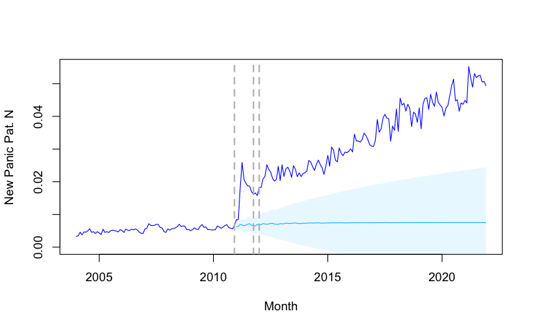

```r
abline(v=c(2004+(which(data$googCha == 100)-1)/120*10,2004+(which(data$googKim == 100)-1)/120*10,2004+(which(data$googLee == 100)-1)/120*10), col="gray", lty="dashed", lwd=2)
```